# Roteiro 4 - Correlação

Luis Felipe Bortolatto da Cunha e Flávia da Fonseca Feitosa

# 1. Introdução

Esse roteiro tem como objetivo ensinar a executar uma **análise de correlação** no software R. Isso inclui a criação de um **diagrama de dispersão**, cálculo do **coeficiente de correlação** e cálculo da estatística teste (**teste de significância**). Adicionalmente, ensina a computar e visualizar uma **matriz de correlação**.

Para executar a análise de correlação vamos utilizar dados demográficos e de consumo de água de 2010, para uma amostra de 4.417 municípios, extraídos do Censo Demográfico (IBGE) e do Sistema Nacional de Informações sobre Saneamento (SNIS), para investigar se **o consumo de água está correlacionado com a renda**, conforme análise apresentada por [Carmo et al., 2013](https://abrh.s3.sa-east-1.amazonaws.com/Sumarios/155/ea6a64ffc76c211d6b7749ab8444b626_bf87b0b219dd784ffa049f367598e626.pdf).

### 1.1. Instalação e importação de pacotes

O software R já conta com funções básicas que permitem executar uma análise de correlação. Mas além das funções básicas, vamos usar os pacotes:

- `haven`: para importar a base de dados em formato `sav` (SPSS)
- `dplyr`: para adicionar o operador `%>%` e a função `select()`
- `corrplot`: para visualizar como gráfico uma matriz de correlação

Se você ainda não possui esses pacotes instalados, é necessário executar o comando abaixo para instalar.

```r
install.packages("haven")
install.packages("dplyr")
install.packages("corrplot")
```

Após a instalação, você pode importá-los com o uso da função `library()`.

```r
library(haven)
library(dplyr)
library(corrplot)
```

### 1.2. Importação da base de dados

Uma base de dados pré-processada está disponível no endereço abaixo: https://github.com/luisfelipebr/mti/blob/master/dados/Agua2010_SNIS.sav?raw=true

Para importá-la é necessário usar a função `read_sav()`.

```r
dados <- read_sav("https://github.com/luisfelipebr/mti/blob/master/dados/Agua2010_SNIS.sav?raw=true")
```

### 1.3. Análise exploratória

A função `names()` exibe os nomes das variáveis.

```r
names(dados)
```

```
##  [1] "ID_IBGE"   "ID_SNIS"   "ID_IBGE_N" "ID_SNIS_N" "MUNICIP1"  "MUNICIP2"
##  [7] "UF"        "REGIAO"    "CENTRX"    "CENTRY"    "RENDAPITA" "GINI"
## [13] "PIB"       "IDH"       "AG001"     "AG020"     "AG022"     "GE012"
## [19] "CONSUMO1"  "CONSUMO2"
```

Como é possível ver após a execução do comando, os nomes das variáveis estão codificados. Mas a tabela abaixo apresenta uma descrição de cada variável.

| Código | Descrição |
| --- | --- |
| ID_IBGE | ID do IBGE (String) |
| ID_SNIS | ID do SNIS (String) |
| ID_IBGE_N | ID do IBGE (Numeric) |
| ID_SNIS_N | ID do SNIS (Numeric) |
| MUNICIP1 | Nome do Municipio 1 |
| MUNICIP2 | Nome do Municipio 2 |
| UF | UF |
| REGIAO | Regiao do pais |
| CENTRX | Centroide (X) |
| CENTRY | Centroide (Y) |
| RENDAPITA | Renda per Capita 2010 |
| GINI | Indice Gini 2010 |
| PIB | PIB 2010 |
| IDH | IDH 2010 |
| AG001 | Populacao Total Atendida com Abastecimento de Agua (AG001) |
| AG020 | Volume Micromedido nas Economias Residenciais Ativas de Agua - 1.000 m3/ano (AG020). |
| AG022 | Quantidade de Economias Residenciais Ativas Micromedidas (AG022) |
| GE012 | Populacao Total Residente no Municipio - IBGE (GE012) |
| CONSUMO1 | Consumo de Agua per capita - Pop Total (AG020/GE012) - m3/ano |
| CONSUMO2 | Consumo de Agua per capita - Pop Atendida (AG020/AG001) - m3/ano |

Vamos usar as variáveis **RENDAPITA** (renda per capita) e **CONSUMO1** (consumo de água per capita) para testar as hipóteses:

- **H0 (hipótese nula):** o consumo de água *não* está correlacionado com a renda
- **H1: (hipótese alternativa)** o consumo de água está correlacionado com a renda

# 2. Diagrama de dispersão

Com o código das variáveis que desejamos investigar em mãos, já é possível criar um **diagrama de dispersão**.

O diagrama de dispersão é um gráfico que **exibe, para cada observação, o valor de uma variável contra o valor em outra variável**, permitindo a **visualização da correlação entre duas variáveis**.

Para construir um diagrama de dispersão, vamos usar a função `plot()` com dois argumentos (x e y), que são as duas variáveis que desejamos investigar a correlação.

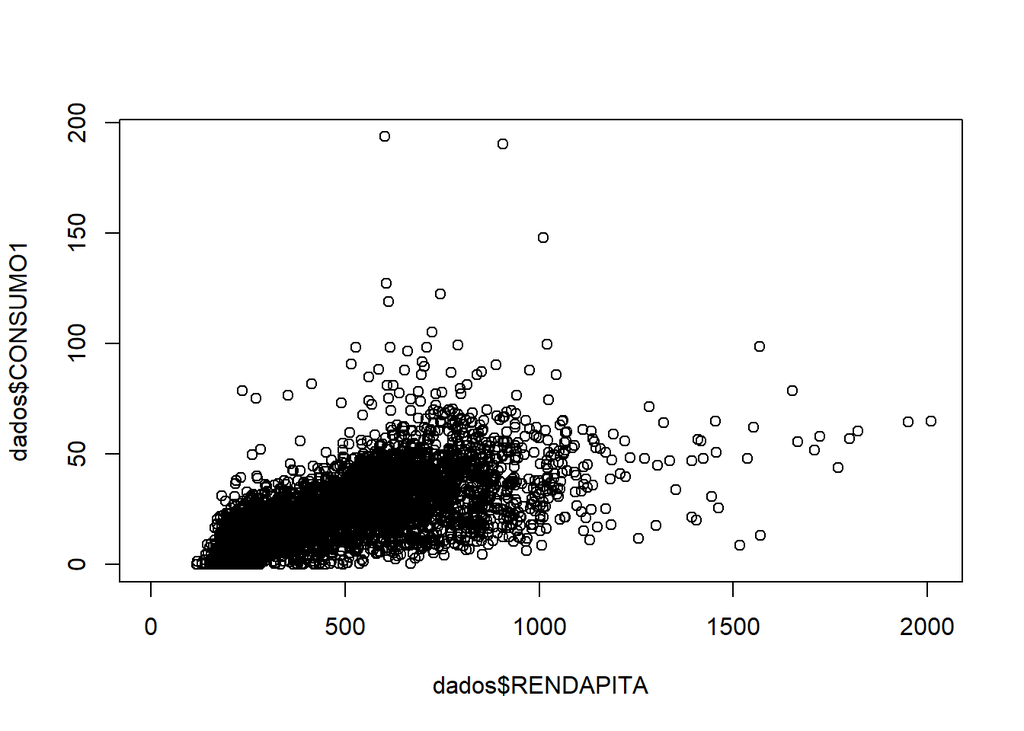

```r
plot(x = dados$RENDAPITA,
     y = dados$CONSUMO1)
```

É possível ainda aprimorar o diagrama de dispersão adicionando alguns argumentos:

- `xlab`: um rótulo para o eixo x
- `ylab`: um rótulo para o eixo y
- Para explorar mais opções, acesse a documentação da função `plot` executando o comando `help(plot)`

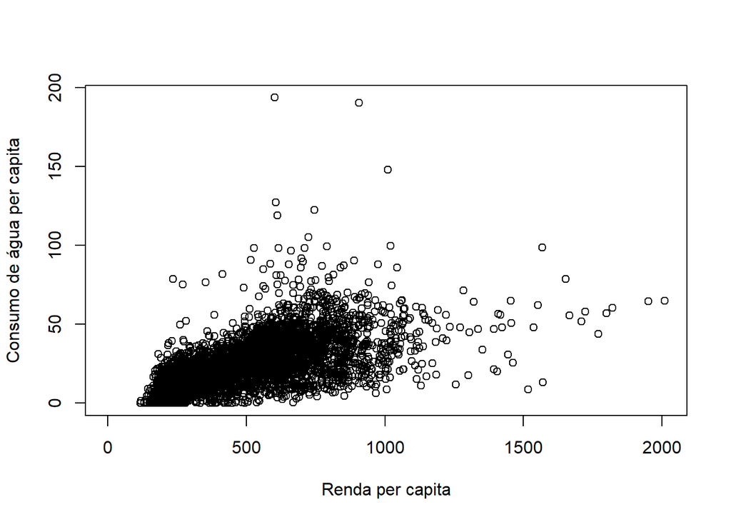

```r
plot(x = dados$RENDAPITA,
     y = dados$CONSUMO1,
     xlab = "Renda per capita",
     ylab = "Consumo de água per capita")
```

O diagrama de dispersão indica que existe uma **correlação positiva** entre as duas variáveis, ou seja, **quanto maior a renda, maior o consumo de água**. Mas vamos verificar essa relação estatísticamente através de um teste de correlação.

# 3. Coeficiente de correlação

Um **coeficiente de correlação** é uma **medida padronizada do relacionamento entre duas variáveis**. O **coeficiente de correlação de Pearson** apresenta um valor entre -1 e 1, sendo que:

- -1 indica uma correlação negativa perfeita
- 0 indica a ausência de relacionamento linear
- 1 indica uma correlação positiva perfeita

Para calcular o coeficiente de correlação de Pearson entre duas variáveis usaremos a função `cor()`, definindo os argumentos:

- `x`: Renda per capita
- `y`: Consumo de Água per capita
- `method = "pearson"`: para calcular o coeficiente de correlação de Pearson (também é possível calcular coeficiente de correlação de Spearman e o Tau de Kendall)
- `use = "complete.obs"`: para remover os valores faltantes (NA)

```r
cor(x = dados$RENDAPITA,
    y = dados$CONSUMO1,
    method = "pearson",
    use = "complete.obs")
```

```
## [1] 0.6012537
```

A correlação entre a Renda e o Consumo de Água é de `0,6`, indicando a mesma **correlação positiva** que o gráfico de dispersão permitiu visualizar.

# 4. Teste de significância

Ainda é necessário confirmar se a correlação não se deve a um erro amostral, ou seja, ao acaso. Para isso vamos realizar um **teste de significância**.

Para testar a significâcia do coeficiente de correlação de Pearson é necessário executar a função `cor.test()`, especificando os argumentos:

- `x`: Renda per capita
- `y`: Consumo de Água per capita
- `method = "pearson"`: para calcular o coeficiente de correlação de Pearson
- `alternative = "two.sided"`: para teste de hipótese bilateral
- `conf.level = 0.95`: define o nível de significância como 0,05

```r
cor.test(x = dados$RENDAPITA,
         y = dados$CONSUMO1,
         method = "pearson",
         alternative = "two.sided",
         conf.level = 0.95)
```

```
##
##  Pearson's product-moment correlation
##
## data:  dados$RENDAPITA and dados$CONSUMO1
## t = 49.997, df = 4415, p-value < 2.2e-16
## alternative hypothesis: true correlation is not equal to 0
## 95 percent confidence interval:
##  0.5820832 0.6197561
## sample estimates:
##       cor
## 0.6012537
```

Como o p-valor (`0,00000000000000022`) é menor que o nível de significância (`0,05`), **rejeitamos a hipótese nula (H0)**, ou seja, os dados indicam que não é possível falsear a hipótese alternativa (H1), sendo uma evidência de que **pode existir uma correlação entre o Consumo de Água e a Renda**.

# 5. (Extra) Matriz de correlação

Quando você estiver explorando a sua hipótese, com os dados do seu trabalho de curso, você pode achar necessário analisar a correlação entre várias duplas de variáveis.

Para construir uma matriz de correlação, primeiro é necessário selecionar as variáveis que deseja investigar (com a função `select()`), para depois calcular o coeficiente de correlação entre cada dupla de variáveis (com a função `cor()`).

```r
dados %>%
  select(RENDAPITA, GINI, PIB, IDH, AG001, AG020, AG022, GE012, CONSUMO1, CONSUMO2) %>%
  cor(method = "pearson",
    use = "complete.obs")
```

```
##            RENDAPITA        GINI        PIB        IDH      AG001      AG020
## RENDAPITA  1.0000000 -0.21207326 0.22656067  0.7441441 0.22452422 0.22066594
## GINI      -0.2120733  1.00000000 0.09122248 -0.3244127 0.10894123 0.09070880
## PIB        0.2265607  0.09122248 1.00000000  0.1197120 0.96136274 0.96136056
## IDH        0.7441441 -0.32441271 0.11971195  1.0000000 0.11862443 0.11392248
## AG001      0.2245242  0.10894123 0.96136274  0.1186244 1.00000000 0.98786350
## AG020      0.2206659  0.09070880 0.96136056  0.1139225 0.98786350 1.00000000
## AG022      0.2254573  0.09683222 0.95324875  0.1187172 0.98333060 0.99036329
## GE012      0.2170024  0.12190523 0.95374843  0.1133372 0.99720483 0.97896439
## CONSUMO1   0.6022883 -0.26515640 0.11826394  0.5176550 0.12109517 0.13689138
## CONSUMO2   0.4936027 -0.25568976 0.06572282  0.4317468 0.05853661 0.08523966
##                AG022      GE012   CONSUMO1    CONSUMO2
## RENDAPITA 0.22545729 0.21700241  0.6022883  0.49360274
## GINI      0.09683222 0.12190523 -0.2651564 -0.25568976
## PIB       0.95324875 0.95374843  0.1182639  0.06572282
## IDH       0.11871717 0.11333722  0.5176550  0.43174677
## AG001     0.98333060 0.99720483  0.1210952  0.05853661
## AG020     0.99036329 0.97896439  0.1368914  0.08523966
## AG022     1.00000000 0.97243354  0.1351452  0.07873208
## GE012     0.97243354 1.00000000  0.1058207  0.04662767
## CONSUMO1  0.13514520 0.10582067  1.0000000  0.85612904
## CONSUMO2  0.07873208 0.04662767  0.8561290  1.00000000
```

Se você quiser facilitar ainda mais a visualização da matriz de correlação, pode adicionar ainda a função `round()` para arredondar os valores do coeficiente de correlação para duas casas decimais.

```r
dados %>%
  select(RENDAPITA, GINI, PIB, IDH, AG001, AG020, AG022, GE012, CONSUMO1, CONSUMO2) %>%
  cor(method = "pearson",
    use = "complete.obs") %>%
  round(digits = 2)
```

```
##           RENDAPITA  GINI  PIB   IDH AG001 AG020 AG022 GE012 CONSUMO1 CONSUMO2
## RENDAPITA      1.00 -0.21 0.23  0.74  0.22  0.22  0.23  0.22     0.60     0.49
## GINI          -0.21  1.00 0.09 -0.32  0.11  0.09  0.10  0.12    -0.27    -0.26
## PIB            0.23  0.09 1.00  0.12  0.96  0.96  0.95  0.95     0.12     0.07
## IDH            0.74 -0.32 0.12  1.00  0.12  0.11  0.12  0.11     0.52     0.43
## AG001          0.22  0.11 0.96  0.12  1.00  0.99  0.98  1.00     0.12     0.06
## AG020          0.22  0.09 0.96  0.11  0.99  1.00  0.99  0.98     0.14     0.09
## AG022          0.23  0.10 0.95  0.12  0.98  0.99  1.00  0.97     0.14     0.08
## GE012          0.22  0.12 0.95  0.11  1.00  0.98  0.97  1.00     0.11     0.05
## CONSUMO1       0.60 -0.27 0.12  0.52  0.12  0.14  0.14  0.11     1.00     0.86
## CONSUMO2       0.49 -0.26 0.07  0.43  0.06  0.09  0.08  0.05     0.86     1.00
```

Também é possível visualizar a matriz de correlação construindo um gráfico, usando a função `corrplot()` do pacote `corrplot`.

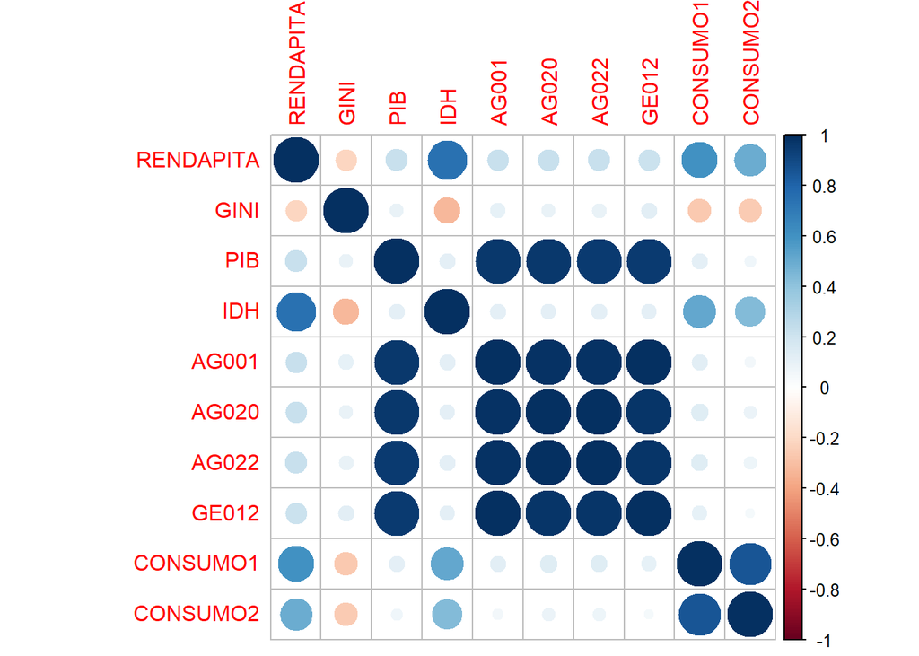

```r
dados %>%
  select(RENDAPITA, GINI, PIB, IDH, AG001, AG020, AG022, GE012, CONSUMO1, CONSUMO2) %>%
  cor(method = "pearson",
    use = "complete.obs") %>%
  corrplot()
```

Manipulando o argumento `method`, você pode testar outras visualizações desse gráfico, conforme indica a documentação da função (`help(corrplot)`) e os exemplos abaixo.

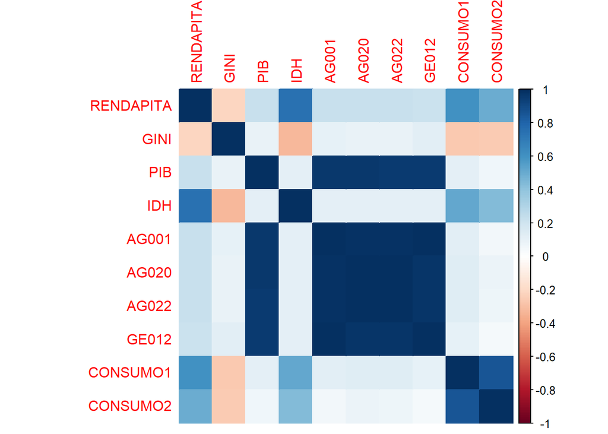

```r
dados %>%
  select(RENDAPITA, GINI, PIB, IDH, AG001, AG020, AG022, GE012, CONSUMO1, CONSUMO2) %>%
  cor(method = "pearson",
    use = "complete.obs") %>%
  corrplot(method = "color")
```

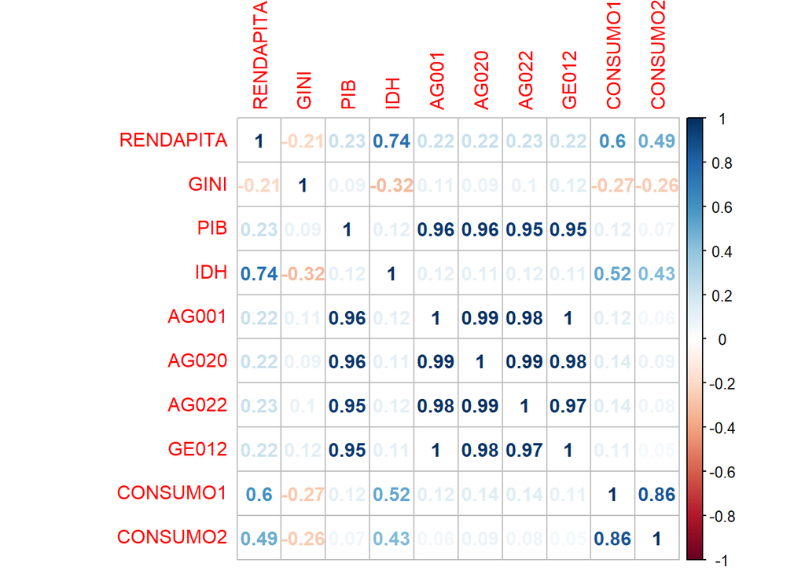

```r
dados %>%
  select(RENDAPITA, GINI, PIB, IDH, AG001, AG020, AG022, GE012, CONSUMO1, CONSUMO2) %>%
  cor(method = "pearson",
    use = "complete.obs") %>%
  corrplot(method = "number")
```

# Tarefa 4

Utilizando os dados do seu trabalho de curso, conduza as seguintes análises no software R:

1. Construa e interprete diagrama(s) de dispersão a partir de variáveis de interesse.
2. Calcule e interprete a correlação entre variáveis de interesse. É significativa? O que isso significa?

A atividade deverá ser compreendida como uma versão preliminar de parte do trabalho final da disciplina. Lembre-se de Caprichar!!! Interprete!!! Aproveite para entender melhor o problema investigado.